# Homework Tidyverse

Author

Ananya Rajan

Published

October 6, 2026

```r
pacman::p_load(tidyverse, gapminder, broom)
```

# Problem 1:

Copy paste and run the tribble given below.

```r
tribble( ~x,    ~y,    ~w,    ~z,
              210,   300,   220,   180,
              102,   100,   119,   187,
              176,   175,   188,   173,
              87,    95,   91,     94,
              202,   210,  234,    218,
              110,   122,  131,    128,
) -> dt
```

## 1_a:

- Use and show a `map` function to find the “mean” of each column of the `dt` data table
- The `map()` function applies the `mean()` function to each column of the `dt` data table. This calculates the average value for each variable separately.

```r
map(dt, mean)
```

```
$x
[1] 147.8333

$y
[1] 167

$w
[1] 163.8333

$z
[1] 163.3333
```

## 1_b:

- Use and show a `map` function to find the “standard deviation” of each column of the `dt` data table.
- The `map()` function applies the `sd()` function to each column of `dt`. This calculates the standard deviation for each variable, which measures how spread out the values are from their mean.

```r
map(dt, sd)
```

```
$x
[1] 54.45151

$y
[1] 79.12016

$w
[1] 58.40348

$z
[1] 44.66617
```

## 1_c:

- Use and show a map function that will calculate the “square root” of each value of each column of the data table `dt`.
- The `map()` function applies the `sqrt()` function to every value in each column of `dt`. This calculates the square root of each observation.

```r
map(dt, sqrt)
```

```
$x
[1] 14.491377 10.099505 13.266499  9.327379 14.212670 10.488088

$y
[1] 17.320508 10.000000 13.228757  9.746794 14.491377 11.045361

$w
[1] 14.832397 10.908712 13.711309  9.539392 15.297059 11.445523

$z
[1] 13.41641 13.67479 13.15295  9.69536 14.76482 11.31371
```

## 1_d:

- Use R code to find the “mean”, “max”, “1st Quartile”, “3rd Quartile”, “Median”, and “Min” for each column of the `dt` data table. (Hint: You do not have to use a map function)
- The `summary()` function calculates several descriptive statistics for each column of `dt`. These include the minimum, first quartile, median, mean, third quartile, and maximum.

```r
summary(dt)
```

```
       x               y               w               z
 Min.   : 87.0   Min.   : 95.0   Min.   : 91.0   Min.   : 94.0
 1st Qu.:104.0   1st Qu.:105.5   1st Qu.:122.0   1st Qu.:139.2
 Median :143.0   Median :148.5   Median :159.5   Median :176.5
 Mean   :147.8   Mean   :167.0   Mean   :163.8   Mean   :163.3
 3rd Qu.:195.5   3rd Qu.:201.2   3rd Qu.:212.0   3rd Qu.:185.2
 Max.   :210.0   Max.   :300.0   Max.   :234.0   Max.   :218.0
```

# Problem 2

## 2_a:

- Repeat part 1 by using a `map_*()` function.
- `map_dbl()` repeats the calculation 10,000 times and returns the results as a numeric vector. During each iteration, `rexp(5, rate = 1)` generates five random observations from an exponential distribution, and `mean()` calculates their mean. The histogram shows the distribution of the resulting 10,000 sample means.

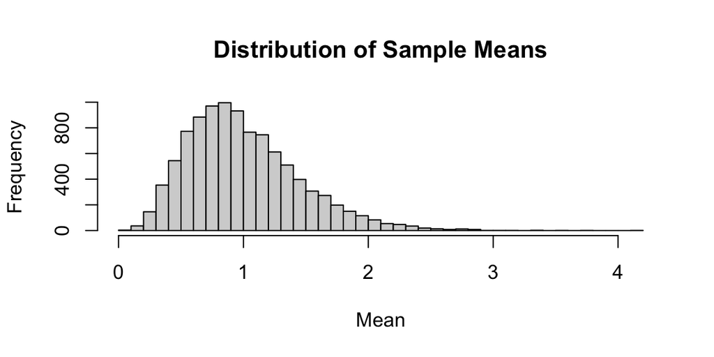

```r
means <- map_dbl(1:10000, ~mean(rexp(5, rate = 1)))

hist(means,
     main = "Distribution of Sample Means",
     xlab = "Mean",
     breaks = 30)
```

## 2_b:

- Repeat part 1 by using the `replicate()` function.
- The `replicate()` function repeats the expression `mean(rexp(5, rate = 1))` 10,000 times. Each repetition generates five observations from the exponential distribution and calculates their mean. The resulting vector of means is then displayed as a histogram.

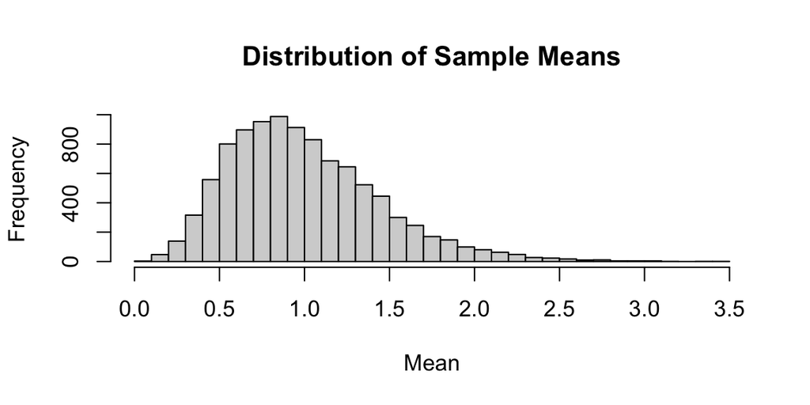

```r
means <- replicate(10000, mean(rexp(5, rate = 1)))

hist(means,
     main = "Distribution of Sample Means",
     xlab = "Mean",
     breaks = 30)
```

## 2_c:

- Use another for loop that will print out plots for sample sizes of 5, 10, and 20 observations.
- The `for` loop runs the simulation for three different sample sizes: 5, 10, and 20 observations. For each sample size, 10,000 sample means are calculated and displayed as a histogram. As the sample size increases, the distribution of sample means becomes narrower and more concentrated around the population mean.

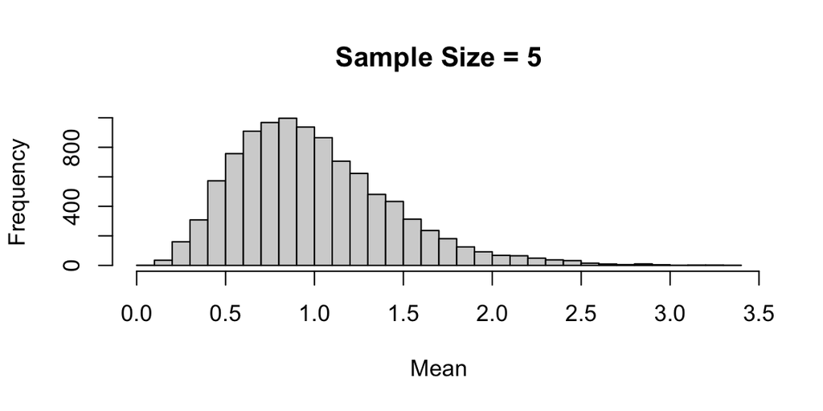

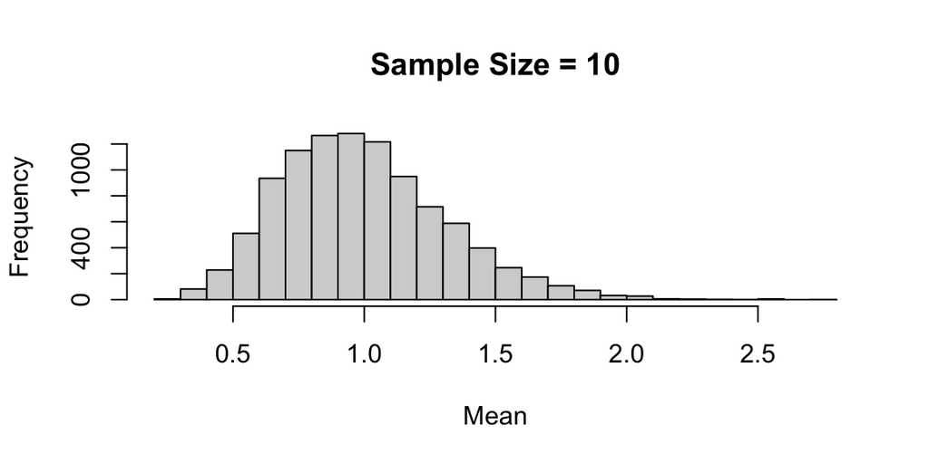

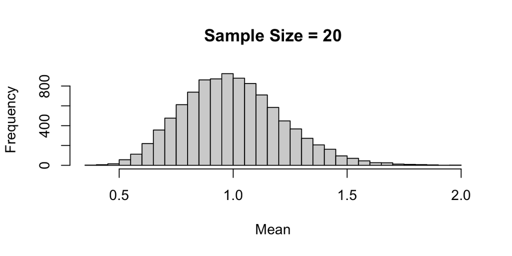

```r
sample_sizes <- c(5, 10, 20)

for (n in sample_sizes) {

  means <- replicate(10000, mean(rexp(n, rate = 1)))

  hist(means,
       main = paste("Sample Size =", n),
       xlab = "Mean",
       breaks = 30)
}
```

# Problem 3:

- Use and show R coding to calculate the “standard deviation” for each variable of the data table `mtcars` using the “Special For Loop Method”.
- The `vector()` function creates an empty numeric vector with one position for each column in `mtcars`. The `for` loop then goes through each column using `seq_along()`. For each column, `sd()` calculates its standard deviation and stores the result in the corresponding position of `output`. Finally, `names(output)` assigns the original column names to the results so that each standard deviation can be identified.

```r
output <- vector("double", ncol(mtcars))

for (i in seq_along(mtcars)) {
  output[[i]] <- sd(mtcars[[i]])
}

output
```

```
 [1]   6.0269481   1.7859216 123.9386938  68.5628685   0.5346787   0.9784574
 [7]   1.7869432   0.5040161   0.4989909   0.7378041   1.6152000
```

```r
output <- vector("double", ncol(mtcars))

for (i in seq_along(mtcars)) {
  output[[i]] <- sd(mtcars[[i]])
}

names(output) <- names(mtcars)
output
```

```
        mpg         cyl        disp          hp        drat          wt
  6.0269481   1.7859216 123.9386938  68.5628685   0.5346787   0.9784574
       qsec          vs          am        gear        carb
  1.7869432   0.5040161   0.4989909   0.7378041   1.6152000
```

# Problem 4

- Generate a sequence of dates from January 1, 2015 to December 31, 2025, spaced by every two months. Extract the year, quarter, and ISO week number for each date.
- `seq.Date()` creates a sequence of dates beginning on January 1, 2015 and continuing through December 31, 2025, with a two-month interval between dates. The `year()` function extracts the year, `quarter()` extracts the quarter of the year, and `isoweek()` extracts the ISO week number. These values are combined into a data frame so that each date and its corresponding information can be viewed together.

```r
dates <- seq.Date(
  from = as.Date("2015-01-01"),
  to = as.Date("2025-12-31"),
  by = "2 months"
)

problem4 <- data.frame(
  date = dates,
  year = year(dates),
  quarter = quarter(dates),
  iso_week = isoweek(dates)
)

problem4
```

```
         date year quarter iso_week
1  2015-01-01 2015       1        1
2  2015-03-01 2015       1        9
3  2015-05-01 2015       2       18
4  2015-07-01 2015       3       27
5  2015-09-01 2015       3       36
6  2015-11-01 2015       4       44
7  2016-01-01 2016       1       53
8  2016-03-01 2016       1        9
9  2016-05-01 2016       2       17
10 2016-07-01 2016       3       26
11 2016-09-01 2016       3       35
12 2016-11-01 2016       4       44
13 2017-01-01 2017       1       52
14 2017-03-01 2017       1        9
```

[output cut: 52 more lines]

# Problem 5

- Given the following dates, compute the difference in months and weeks between each consecutive pair.

sample_dates <- c(“2018-03-15”, “2020-07-20”, “2023-01-10”, “2025-09-05”)

- First, the character strings are converted into Date objects using `as.Date()`. The dates are then compared in consecutive pairs. `interval()` and `months(1)` are used to calculate the number of completed months between each pair of dates. `difftime()` calculates the elapsed time in weeks. Finally, `data.frame()` combines the starting date, ending date, month difference, and week difference into a table.

```r
sample_dates <- c("2018-03-15", "2020-07-20", "2023-01-10", "2025-09-05")

sample_dates <- as.Date(sample_dates)

months_diff <- interval(sample_dates[-length(sample_dates)],
                        sample_dates[-1]) %/% months(1)

weeks_diff <- as.numeric(
  difftime(sample_dates[-1], sample_dates[-length(sample_dates)], units = "weeks")
)

data.frame(
  from = sample_dates[-length(sample_dates)],
  to = sample_dates[-1],
  months = months_diff,
  weeks = weeks_diff
)
```

```
        from         to months    weeks
1 2018-03-15 2020-07-20     28 122.5714
2 2020-07-20 2023-01-10     29 129.1429
3 2023-01-10 2025-09-05     31 138.4286
```

# Problem 6

- Given a list of mixed date formats, use `map()` and `possibly()` from `purrr` to safely convert them to **Date** format and extract the **month name**.
- The dates are stored as a list because they have different formats. The `possibly()` function creates a safe version of the date-parsing function so that an invalid date does not cause the entire operation to fail. `parse_date_time()` attempts to recognize the different date formats. `map()` applies this safe parsing function to every item in the list. The invalid date is returned as `NA`. Finally, `map_chr()` extracts the full month name from each valid date while keeping the invalid date as `NA`.

```r
date_strings <- list(
  "2023-06-10",
  "2022/12/25",
  "15-Aug-2021",
  "InvalidDate"
)

safe_parse <- possibly(
  function(x) {
    suppressWarnings(
      parse_date_time(x, orders = c("ymd", "dmy"))
    )
  },
  otherwise = NA
)

dates <- map(date_strings, safe_parse)

month_names <- map_chr(
  dates,
  function(x) {
    if (is.na(x)) {
      return(NA_character_)
    } else {
      return(as.character(month(x, label = TRUE, abbr = FALSE)))
    }
  }
)

month_names
```

```
[1] "June"     "December" "August"   NA
```